# Intro to Statistics and Data Analysis with R (0560.1823)

TV Shows- A platformwise analysis

Lian Brave, Rawan Awawde, Shada saleh

27.06.2021

[figure not shown]

# Background

This TV_shows dataset comprises a comprehensive list of tv shows available on various streaming platforms such as Netflix, Hulu, Disney+ and Prime Video.  
Ratings for these shows is also available in the form of IMDB and Rotten Tomatoes.  
We notice that the dataset also shows the target age group against a particular show is interested in as well as the year the show was originally published in.

[figure not shown]

This data was taken from Kaggle with this link: https://www.kaggle.com/ruchi798/tv-shows-on-netflix-prime-video-hulu-and-disney

## Loading the initial packages.

```r
library(rattle) #using it for free graphical interface for data
library(magrittr) # in order to utilise %>% and %<>% pipeline operators.
library(Hmisc, quietly=TRUE) # The 'Hmisc' package provides the 'contents' function.
library(fBasics, quietly=TRUE)
library(skimr) #skimr is designed to provide summary statistics about variables in data frames
library(rmarkdown) #Convert R Markdown documents into a variety of formats including HTML, MS Word, PDF, and Beamer.٠
library(DT) #The main function in this package is datatable. It creates an HTML widget to display R data objects with DataTables.
library(corrplot, quietly=TRUE) #The 'corrplot' package provides the 'corrplot' function.
library(readxl)
library(tidyverse)
library(gridExtra) #helps to arrange multiple grid-based plots on a page, and draw tables.
```

## Set Seed

A pre-defined value is used to reset the random seed so that results are repeatable.

```r
crv$seed <- 42
```

## Load a dataset from file.

```r
fname <- "C:/Users/user/Desktop/Group 37/tv_shows.csv"
TV_shows <- read.csv(fname,
            na.strings=c(".", "NA", "", "?"),
            strip.white=TRUE, encoding="UTF-8")
#na.strings=All the entries having NA,".","","?" will be converted into na.
TV_shows$Rotten.Tomatoes <- as.numeric(sub("%","",TV_shows$Rotten.Tomatoes))/100
```

# Tidying the Dataset

```r
set.seed(crv$seed)
# The following variable selections have been noted for easy using in coding.
# SHOWnumeric - just the numeric columns
# SHOWinput - all the columns (data)
# SHOWcategoric - has just a categoric columns
#we will make new variables along with the project according to what we need.

SHOWinput     <- c("Title", "Age", "IMDb", "Rotten.Tomatoes",
                   "Netflix", "Hulu", "Prime.Video", "Disney.")

SHOWnumeric   <- c("IMDb", "Netflix", "Hulu", "Prime.Video",
                   "Disney.")

SHOWcategoric <- c("Title", "Age", "Rotten.Tomatoes")

SHOWtarget    <- "Year"
SHOWrisk      <- NULL

Rate =ceiling(as.numeric(TV_shows$IMDb))
TV_shows<-TV_shows%>%
  mutate(Rate)
```

# Exploratory Data Analysis(EDA)

EDA is primarily used to see what data can reveal beyond the formal modeling or hypothesis testing task and provides a better understanding of data set variables and the relationships between them. It will also help us determine if the statistical techniques we are considering for data analysis are appropriate.

## Summarizing the Data

Looking at the contents of the data.

```r
# Obtain a summary of the dataset.
contents(TV_shows)
```

```
##
## Data frame:TV_shows  5611 observations and 12 variables    Maximum # NAs:4600
##
##
##                   Storage  NAs
## X                 integer    0
## Title           character    0
## Year              integer    0
## Age             character 2446
## IMDb               double 1161
## Rotten.Tomatoes    double 4600
## Netflix           integer    0
## Hulu              integer    0
## Prime.Video       integer    0
## Disney.           integer    0
## type              integer    0
## Rate               double 1161
```

```r
summary(TV_shows)
```

```
##        X           Title                Year          Age
##  Min.   :   0   Length:5611        Min.   :1901   Length:5611
##  1st Qu.:1402   Class :character   1st Qu.:2010   Class :character
##  Median :2805   Mode  :character   Median :2015   Mode  :character
##  Mean   :2805                      Mean   :2011
##  3rd Qu.:4208                      3rd Qu.:2017
##  Max.   :5610                      Max.   :2020
##
##       IMDb       Rotten.Tomatoes    Netflix            Hulu
##  Min.   :1.000   Min.   :0.060   Min.   :0.0000   Min.   :0.0000
##  1st Qu.:6.600   1st Qu.:0.670   1st Qu.:0.0000   1st Qu.:0.0000
##  Median :7.300   Median :0.830   Median :0.0000   Median :0.0000
##  Mean   :7.113   Mean   :0.775   Mean   :0.3441   Mean   :0.3126
##  3rd Qu.:7.900   3rd Qu.:0.930   3rd Qu.:1.0000   3rd Qu.:1.0000
##  Max.   :9.600   Max.   :1.000   Max.   :1.0000   Max.   :1.0000
##  NA's   :1161    NA's   :4600
##   Prime.Video        Disney.             type        Rate
##  Min.   :0.0000   Min.   :0.00000   Min.   :1   Min.   : 1.000
##  1st Qu.:0.0000   1st Qu.:0.00000   1st Qu.:1   1st Qu.: 7.000
##  Median :0.0000   Median :0.00000   Median :1   Median : 8.000
##  Mean   :0.3821   Mean   :0.03208   Mean   :1   Mean   : 7.574
##  3rd Qu.:1.0000   3rd Qu.:0.00000   3rd Qu.:1   3rd Qu.: 8.000
##  Max.   :1.0000   Max.   :1.00000   Max.   :1   Max.   :10.000
##                                                 NA's   :1161
```

## Another Way for Summarizing All the Data:

```r
#Display the Structure of the data table
str(TV_shows)
```

```
## 'data.frame':    5611 obs. of  12 variables:
##  $ X              : int  0 1 2 3 4 5 6 7 8 9 ...
##  $ Title          : chr  "Breaking Bad" "Stranger Things" "Money Heist" "Sherlock" ...
##  $ Year           : int  2008 2016 2017 2010 2015 2005 2011 2005 2013 2005 ...
##  $ Age            : chr  "18+" "16+" "18+" "16+" ...
##  $ IMDb           : num  9.5 8.8 8.4 9.1 8.7 8.9 8.8 8.4 8.8 9.2 ...
##  $ Rotten.Tomatoes: num  0.96 0.93 0.91 0.78 0.97 0.81 0.83 0.93 0.92 1 ...
##  $ Netflix        : int  1 1 1 1 1 1 1 1 1 1 ...
##  $ Hulu           : int  0 0 0 0 0 0 0 0 0 0 ...
##  $ Prime.Video    : int  0 0 0 0 0 0 0 0 0 0 ...
##  $ Disney.        : int  0 0 0 0 0 0 0 0 0 0 ...
##  $ type           : int  1 1 1 1 1 1 1 1 1 1 ...
##  $ Rate           : num  10 9 9 10 9 9 9 9 9 10 ...
```

```r
# skim: an alternative summary,provides summary statistics about variables
skim(TV_shows)
```

Data summary

| Name | TV_shows |
| --- | --- |
| Number of rows | 5611 |
| Number of columns | 12 |
| _______________________ |  |
| Column type frequency: |  |
| character | 2 |
| numeric | 10 |
| ________________________ |  |
| Group variables | None |

**Variable type: character**

| skim_variable | n_missing | complete_rate | min | max | empty | n_unique | whitespace |
| --- | --- | --- | --- | --- | --- | --- | --- |
| Title | 0 | 1.00 | 2 | 77 | 0 | 5564 | 0 |
| Age | 2446 | 0.56 | 2 | 3 | 0 | 5 | 0 |

**Variable type: numeric**

| skim_variable | n_missing | complete_rate | mean | sd | p0 | p25 | p50 | p75 | p100 | hist |
| --- | --- | --- | --- | --- | --- | --- | --- | --- | --- | --- |
| X | 0 | 1.00 | 2805.00 | 1619.90 | 0.00 | 1402.50 | 2805.00 | 4207.50 | 5610.0 | ▇▇▇▇▇ |
| Year | 0 | 1.00 | 2011.02 | 11.01 | 1901.00 | 2010.00 | 2015.00 | 2017.00 | 2020.0 | ▁▁▁▁▇ |
| IMDb | 1161 | 0.79 | 7.11 | 1.13 | 1.00 | 6.60 | 7.30 | 7.90 | 9.6 | ▁▁▂▇▃ |
| Rotten.Tomatoes | 4600 | 0.18 | 0.78 | 0.21 | 0.06 | 0.67 | 0.83 | 0.93 | 1.0 | ▁▁▂▃▇ |
| Netflix | 0 | 1.00 | 0.34 | 0.48 | 0.00 | 0.00 | 0.00 | 1.00 | 1.0 | ▇▁▁▁▅ |
| Hulu | 0 | 1.00 | 0.31 | 0.46 | 0.00 | 0.00 | 0.00 | 1.00 | 1.0 | ▇▁▁▁▃ |
| Prime.Video | 0 | 1.00 | 0.38 | 0.49 | 0.00 | 0.00 | 0.00 | 1.00 | 1.0 | ▇▁▁▁▅ |
| Disney. | 0 | 1.00 | 0.03 | 0.18 | 0.00 | 0.00 | 0.00 | 0.00 | 1.0 | ▇▁▁▁▁ |
| type | 0 | 1.00 | 1.00 | 0.00 | 1.00 | 1.00 | 1.00 | 1.00 | 1.0 | ▁▁▇▁▁ |
| Rate | 1161 | 0.79 | 7.57 | 1.17 | 1.00 | 7.00 | 8.00 | 8.00 | 10.0 | ▁▁▂▇▂ |

```r
# display the Data
paged_table(head(TV_shows), options = list(rows.print = 10))
```

|  | X | Title | Year | Age | IMDb | Rotten.Tomatoes | Netflix | Hulu | Prime.Video | Disney. | type | Rate |
| --- | --- | --- | --- | --- | --- | --- | --- | --- | --- | --- | --- | --- |
| 1 | 0 | Breaking Bad | 2008 | 18+ | 9.5 | 0.96 | 1 | 0 | 0 | 0 | 1 | 10 |
| 2 | 1 | Stranger Things | 2016 | 16+ | 8.8 | 0.93 | 1 | 0 | 0 | 0 | 1 | 9 |
| 3 | 2 | Money Heist | 2017 | 18+ | 8.4 | 0.91 | 1 | 0 | 0 | 0 | 1 | 9 |
| 4 | 3 | Sherlock | 2010 | 16+ | 9.1 | 0.78 | 1 | 0 | 0 | 0 | 1 | 10 |
| 5 | 4 | Better Call Saul | 2015 | 18+ | 8.7 | 0.97 | 1 | 0 | 0 | 0 | 1 | 9 |
| 6 | 5 | The Office | 2005 | 16+ | 8.9 | 0.81 | 1 | 0 | 0 | 0 | 1 | 9 |

```r
# Another method to display all the data in a convenient way
datatable(TV_shows)
```

|  | X | Title | Year | Age | IMDb | Rotten.Tomatoes | Netflix | Hulu | Prime.Video | Disney. | type | Rate |
| --- | --- | --- | --- | --- | --- | --- | --- | --- | --- | --- | --- | --- |
| 1 | 0 | Breaking Bad | 2008 | 18+ | 9.5 | 0.96 | 1 | 0 | 0 | 0 | 1 | 10 |
| 2 | 1 | Stranger Things | 2016 | 16+ | 8.8 | 0.93 | 1 | 0 | 0 | 0 | 1 | 9 |
| 3 | 2 | Money Heist | 2017 | 18+ | 8.4 | 0.91 | 1 | 0 | 0 | 0 | 1 | 9 |
| 4 | 3 | Sherlock | 2010 | 16+ | 9.1 | 0.78 | 1 | 0 | 0 | 0 | 1 | 10 |
| 5 | 4 | Better Call Saul | 2015 | 18+ | 8.7 | 0.97 | 1 | 0 | 0 | 0 | 1 | 9 |
| 6 | 5 | The Office | 2005 | 16+ | 8.9 | 0.81 | 1 | 0 | 0 | 0 | 1 | 9 |
| 7 | 6 | Black Mirror | 2011 | 18+ | 8.8 | 0.83 | 1 | 0 | 0 | 0 | 1 | 9 |
| 8 | 7 | Supernatural | 2005 | 16+ | 8.4 | 0.93 | 1 | 0 | 0 | 0 | 1 | 9 |
| 9 | 8 | Peaky Blinders | 2013 | 18+ | 8.8 | 0.92 | 1 | 0 | 0 | 0 | 1 | 9 |
| 10 | 9 | Avatar: The Last Airbender | 2005 | 7+ | 9.2 | 1 | 1 | 0 | 0 | 0 | 1 | 10 |

[output cut: 5601 more lines]

# Describing the Data

The ‘Hmisc’ package provides the ‘describe’ function.  
The description shows the missing and distinct values.

```r
# Generate a description of the dataset.

describe(TV_shows)
```

```
## TV_shows
##
##  12  Variables      5611  Observations
## --------------------------------------------------------------------------------
## X
##        n  missing distinct     Info     Mean      Gmd      .05      .10
##     5611        0     5611        1     2805     1871    280.5    561.0
##      .25      .50      .75      .90      .95
##   1402.5   2805.0   4207.5   5049.0   5329.5
##
## lowest :    0    1    2    3    4, highest: 5606 5607 5608 5609 5610
## --------------------------------------------------------------------------------
## Title
##        n  missing distinct
##     5611        0     5564
##
## lowest : #blackAF                          #MeToo, Now What?                 #ThatsHarassment                  (The Hook Up Plan)                .hack
## highest: Zoo Babies                        Zorro the Chronicles              Zou                               Zumba Awesome Legs & Booty System Zumbo's Just Desserts
## --------------------------------------------------------------------------------
## Year
##        n  missing distinct     Info     Mean      Gmd      .05      .10
##     5611        0       81    0.995     2011    9.371     1990     2000
##      .25      .50      .75      .90      .95
##     2010     2015     2017     2019     2019
##
## lowest : 1901 1904 1914 1931 1932, highest: 2016 2017 2018 2019 2020
## --------------------------------------------------------------------------------
## Age
##        n  missing distinct
##     3165     2446        5
##
## lowest : 13+ 16+ 18+ 7+  all, highest: 13+ 16+ 18+ 7+  all
##
## Value        13+   16+   18+    7+   all
## Frequency      4  1018   750   848   545
## Proportion 0.001 0.322 0.237 0.268 0.172
## --------------------------------------------------------------------------------
## IMDb
##        n  missing distinct     Info     Mean      Gmd      .05      .10
##     4450     1161       78    0.999    7.113    1.215      5.0      5.6
```

[output cut: 38 more lines]

```
## Frequency  5611
## Proportion    1
## --------------------------------------------------------------------------------
## Rate
##        n  missing distinct     Info     Mean      Gmd      .05      .10
##     4450     1161       10    0.911    7.574    1.221        5        6
##      .25      .50      .75      .90      .95
##        7        8        8        9        9
##
## lowest :  1  2  3  4  5, highest:  6  7  8  9 10
##
## Value          1     2     3     4     5     6     7     8     9    10
## Frequency      1     6    22    65   151   404  1130  1787   859    25
## Proportion 0.000 0.001 0.005 0.015 0.034 0.091 0.254 0.402 0.193 0.006
## --------------------------------------------------------------------------------
```

# Visulations

*In a boxplot, the midline is the median of your data, with the upper and lower limits of the box being the third and first quartile1 (75th and 25th percentile).* *For each box plots, the mean indicated by the ٭*

## Use ggplot2 to generate box plots

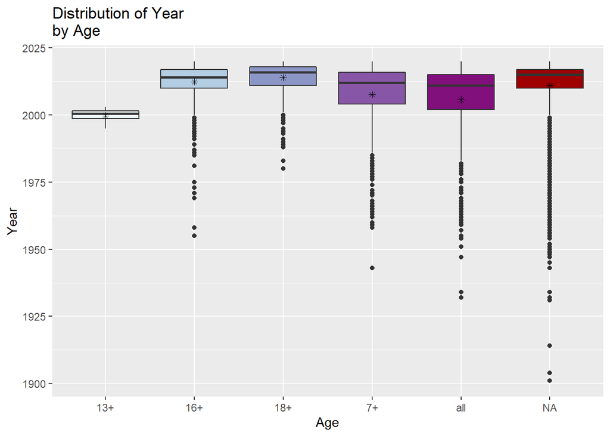

```r
p01 <- TV_shows[,] %>%
  mutate(Age=as.factor(Age)) %>%
  ggplot(aes(y=Year)) +
  geom_boxplot(aes(x="NA"), notch=FALSE, fill="#9f0002") +
  stat_summary(aes(x="NA"), fun=mean, geom="point", shape=8) +
  geom_boxplot(aes(x=Age, fill=Age), notch=FALSE)+
  stat_summary(aes(x=Age), fun=mean, geom="point", shape=8) +
  xlab("Age") +
  ggtitle("Distribution of Year \nby Age") +
  scale_fill_brewer(palette="BuPu")+
  theme(legend.position="none")

# Display the plots.
grid.arrange(p01)
```

*It is clear from the above figure that movies for ages 18+ is relatively have the latest movies than the rest.Also as we can see Outliers are observed when data is grouped by all ages.*

## Use ggplot2 to generate bar plot for IMDb rating.

[figure not shown]

```r
rating_data<-TV_shows %>%
  group_by(Rate) %>%
  tally %>%
  filter(!is.na(Rate))

ggplot(rating_data, aes(x=Rate, y=n)) +
  geom_bar(aes(color = Rate,
               fill=Rate),
           stat='identity',
           colour="black",
           position=position_dodge())+
  xlab("IMDb Rating") +
  ylab("TV Shows") +
  ggtitle("TV Shows By IMDb Rating") +
  theme_bw() +
  theme(plot.title = element_text(hjust=0.5,size = 20))+
  xlim("1", "2", "3", "4", "5" , "6", "7", "8", "9", "10")
```

## Use ggplot2 to generate box plot for Netflix

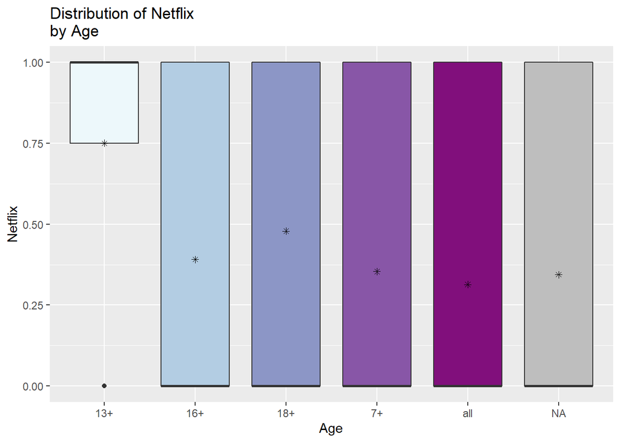

```r
p01 <- TV_shows[,] %>%
  mutate(Age=as.factor(Age)) %>%
  ggplot(aes(y=Netflix)) +
  geom_boxplot(aes(x="NA"), notch=FALSE, fill="grey") +
  stat_summary(aes(x="NA"), fun=mean, geom="point", shape=8) +
  geom_boxplot(aes(x=Age, fill=Age), notch=FALSE) +
  stat_summary(aes(x=Age), fun=mean, geom="point", shape=8) +
  xlab("Age") +
  ggtitle("Distribution of Netflix \nby Age") +
  scale_fill_brewer(palette="BuPu")+
  theme(legend.position="none")

# Display the plots.
grid.arrange(p01)
```

## Use ggplot2 to generate box plot for Hulu

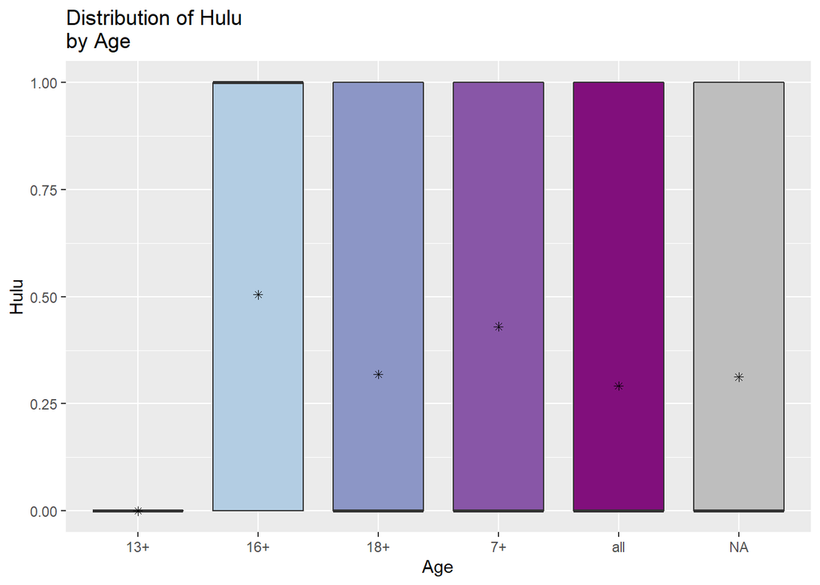

```r
p01 <- TV_shows[,] %>%
  mutate(Age=as.factor(Age)) %>%
  ggplot(aes(y=Hulu)) +
  geom_boxplot(aes(x="NA"), notch=FALSE, fill="grey") +
  stat_summary(aes(x="NA"), fun=mean, geom="point", shape=8) +
  geom_boxplot(aes(x=Age, fill=Age), notch=FALSE) +
  stat_summary(aes(x=Age), fun=mean, geom="point", shape=8) +
  xlab("Age") +
  ggtitle("Distribution of Hulu \nby Age") +
  scale_fill_brewer(palette="BuPu")+
  theme(legend.position="none")

# Display the plots.
grid.arrange(p01)
```

## Use ggplot2 to generate box plot for Prime.Video

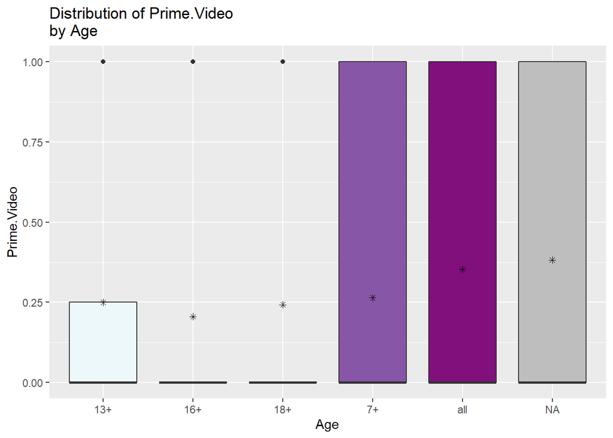

```r
p01 <- TV_shows[,] %>%
  mutate(Age=as.factor(Age)) %>%
  ggplot(aes(y=Prime.Video)) +
  geom_boxplot(aes(x="NA"), notch=FALSE, fill="grey") +
  stat_summary(aes(x="NA"), fun=mean, geom="point", shape=8) +
  geom_boxplot(aes(x=Age, fill=Age), notch=FALSE) +
  stat_summary(aes(x=Age), fun=mean, geom="point", shape=8) +
  xlab("Age") +
  ggtitle("Distribution of Prime.Video \nby Age") +
  scale_fill_brewer(palette="BuPu")+
  theme(legend.position="none")

# Display the plots.
grid.arrange(p01)
```

## Use ggplot2 to generate box plot for Disney.

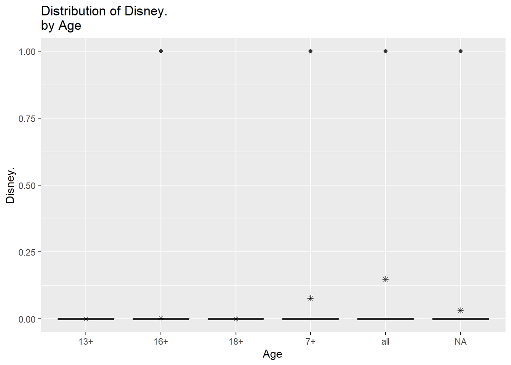

```r
p01 <- TV_shows[,] %>%
  mutate(Age=as.factor(Age)) %>%
  ggplot(aes(y=Disney.)) +
  geom_boxplot(aes(x="NA"), notch=FALSE, fill="grey") +
  stat_summary(aes(x="NA"), fun=mean, geom="point", shape=8) +
  geom_boxplot(aes(x=Age, fill=Age), notch=FALSE) +
  stat_summary(aes(x=Age), fun=mean, geom="point", shape=8) +
  xlab("Age") +
  ggtitle("Distribution of Disney. \nby Age") +
  scale_fill_brewer(palette="BuPu")+
  theme(legend.position="none")

# Display the plots.
grid.arrange(p01)
```

## Boxplot of Rotten Tomatoes by Age

[figure not shown]

```r
p01 <- TV_shows[,] %>%
  select(Rotten.Tomatoes, Age) %>%
  ggplot(aes(y=Rotten.Tomatoes)) +
    geom_boxplot(aes(x="NA"), notch=FALSE, fill="grey") +
    stat_summary(aes(x="NA"), fun=mean, geom="point", shape=8) +
    geom_boxplot(aes(x=Age, fill=Age), notch=FALSE) +
    stat_summary(aes(x=Age), fun=mean, geom="point", shape=8) +
    xlab("Age") +
    ggtitle("Distribution of Rotten Tomatoes \nby Age") +
    scale_fill_brewer(palette="BuPu")+
    theme(legend.position="none")

# Display the plots.
grid.arrange(p01)
```

*Its clear that the movies for 13+ gave the lowest Rotten Tomatoes rating, while the other movies relatively have a similar median Rotten Tomatoes values around 80%.*

## Use ggplot2 to generate density plot for Year

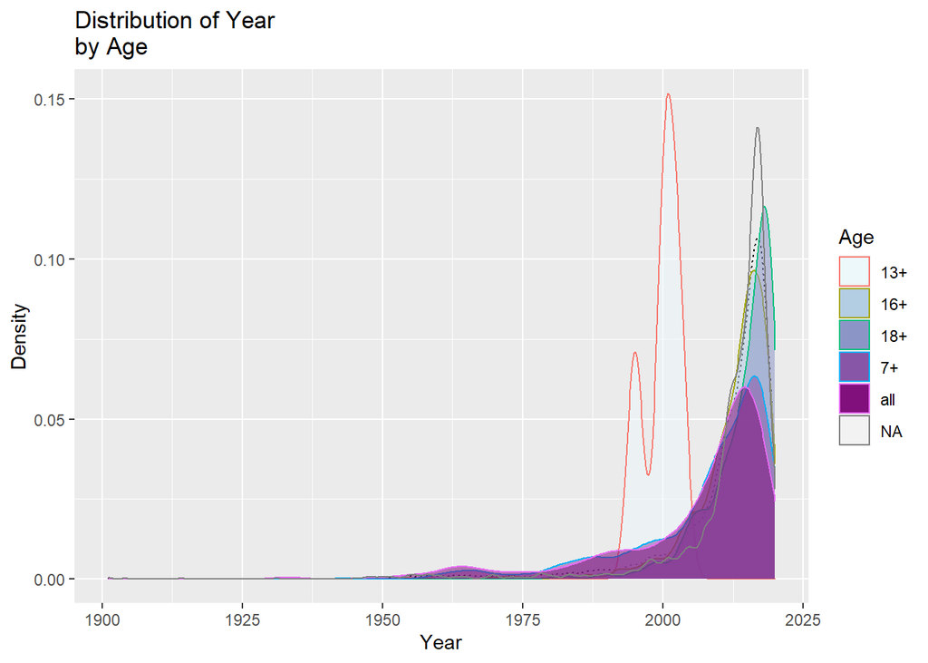

```r
p01 <- TV_shows[,] %>%
  mutate(Age=as.factor(Age)) %>%
  select(Year, Age) %>%
  ggplot(aes(x=Year)) +
  geom_density(lty=3) +
  geom_density(aes(fill=Age, colour=Age), alpha=0.55) +
  xlab("Year") +
  ggtitle("Distribution of Year \nby Age") +
  scale_fill_brewer(palette="BuPu")+
  labs(fill="Age", y="Density")

# Display the plots.
grid.arrange(p01)
```

*At this density plot as we can see most of the movies for age 13+ were produced in 2000 (has the high point of density), however, for the other age ranges, production year is left skewed and centered around nearly 2015.*

## Use ggplot2 to generate density plot for IMDb

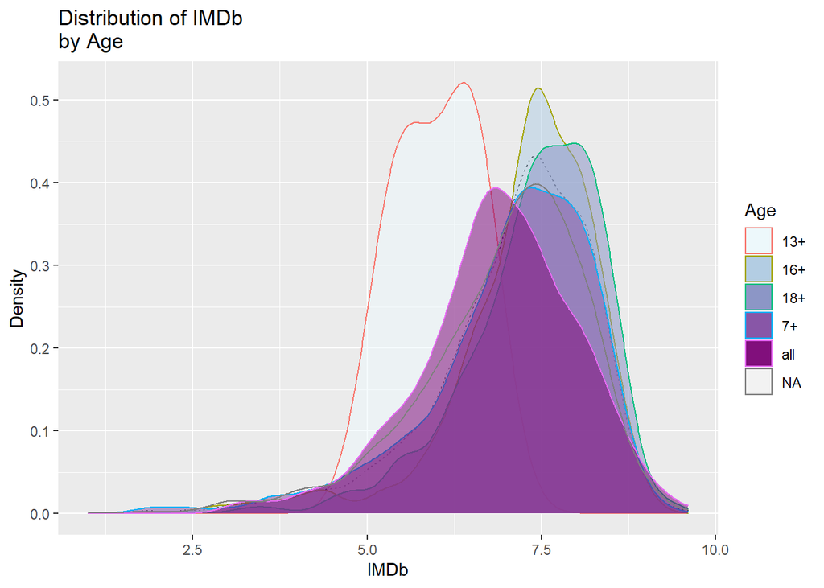

```r
p01 <- TV_shows[,] %>%
  mutate(Age=as.factor(Age)) %>%
  select(IMDb, Age) %>%
  ggplot(aes(x=IMDb)) +
  geom_density(lty=3) +
  geom_density(aes(fill=Age, colour=Age), alpha=0.55) +
  xlab("IMDb") +
  ggtitle("Distribution of IMDb \nby Age") +
  scale_fill_brewer(palette="BuPu")+
  labs(fill="Age", y="Density")

# Display the plots.
grid.arrange(p01)
```

*Here as we can see there are two “humps” by ages +13 at this distribution. A possible explanation to this is:the difference of values for the movie production quality (those who have a good production had a higher IMDb, for example). All the values of ages are left skewed with different IMDb mean .*

## Use ggplot2 to generate density plot for Netflix

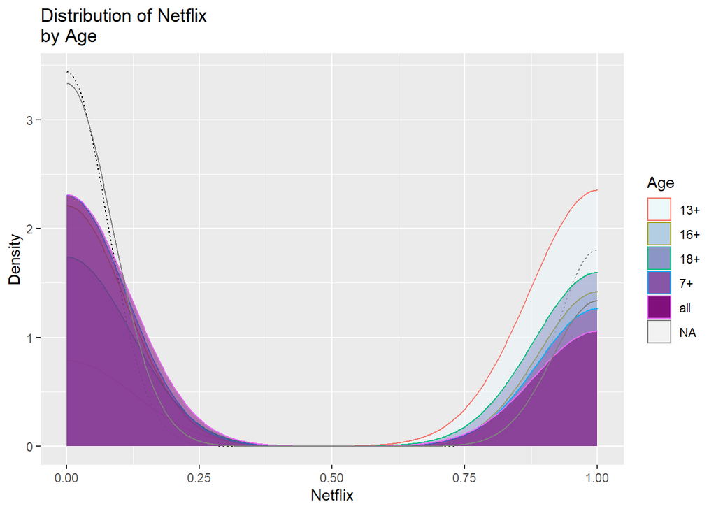

```r
p01 <- TV_shows[,] %>%
  mutate(Age=as.factor(Age)) %>%
  select(Netflix, Age) %>%
  ggplot(aes(x=Netflix)) +
  geom_density(lty=3) +
  geom_density(aes(fill=Age, colour=Age), alpha=0.55) +
  xlab("Netflix") +
  ggtitle("Distribution of Netflix \nby Age") +
  scale_fill_brewer(palette="BuPu")+
  labs(fill="Age", y="Density")

# Display the plots.
grid.arrange(p01)
```

*The distribution of Netflix production movies by age have two peaks: one at 0 and the other one at 1 and that is because the variable Netflix is binary and they represent two local maximums; these are points where the data points stop increasing and start decreasing.*

## Use ggplot2 to generate density plot for Hulu

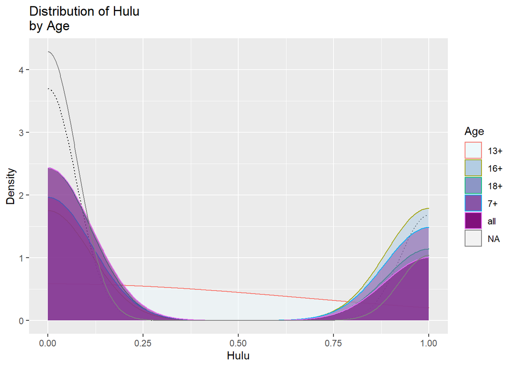

```r
p01 <- TV_shows[,] %>%
  mutate(Age=as.factor(Age)) %>%
  select(Hulu, Age) %>%
  ggplot(aes(x=Hulu)) +
  geom_density(lty=3) +
  geom_density(aes(fill=Age, colour=Age), alpha=0.55) +
  xlab("Hulu") +
  ggtitle("Distribution of Hulu \nby Age") +
    scale_fill_brewer(palette="BuPu")+
  labs(fill="Age", y="Density")

# Display the plots.
grid.arrange(p01)
```

*We can see there are two “humps” but this time by all ages. So here also the same possible explanation for this density plot .*

## Use ggplot2 to generate density plot for Prime.Video

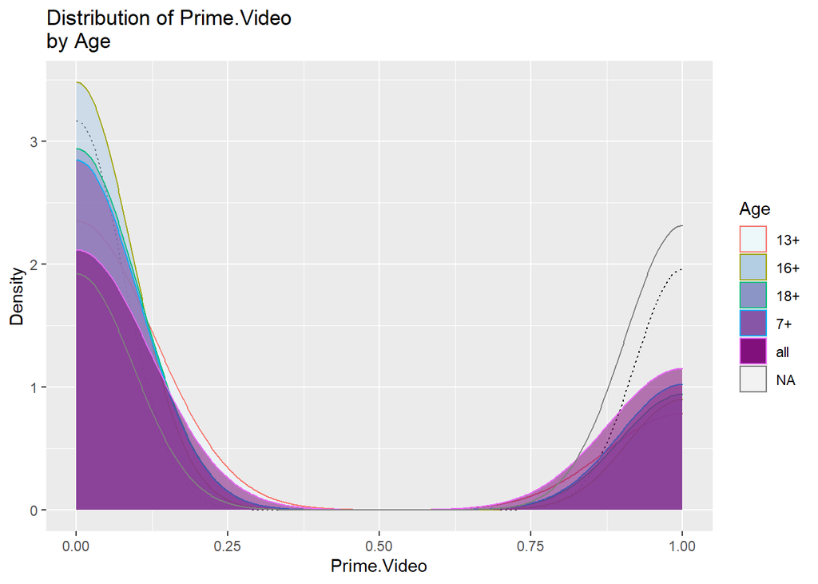

```r
p01 <- TV_shows[,] %>%
  mutate(Age=as.factor(Age)) %>%
  select(Prime.Video, Age) %>%
  ggplot(aes(x=Prime.Video)) +
  geom_density(lty=3) +
  geom_density(aes(fill=Age, colour=Age), alpha=0.55) +
  xlab("Prime.Video") +
  ggtitle("Distribution of Prime.Video \nby Age") +
  scale_fill_brewer(palette="BuPu")+
  labs(fill="Age", y="Density")

# Display the plots.
grid.arrange(p01)
```

*this density is almost like the density plot for Netflix, we can see there are two “humps” for all ages,with the same possible explanation.*

## Use ggplot2 to generate density plot for Disney.

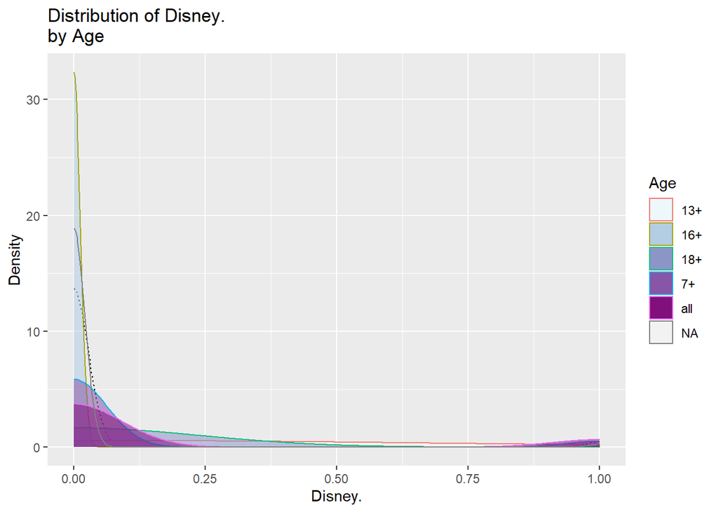

```r
p01 <- TV_shows[,] %>%
  mutate(Age=as.factor(Age)) %>%
  select(Disney., Age) %>%
  ggplot(aes(x=Disney.)) +
  geom_density(lty=3) +
  geom_density(aes(fill=Age, colour=Age), alpha=0.55) +
  xlab("Disney.") +
  ggtitle("Distribution of Disney. \nby Age") +
  scale_fill_brewer(palette="BuPu")+
  labs(fill="Age", y="Density")

# Display the plots.
grid.arrange(p01)
```

## Barplot for Rotten Tomatoes

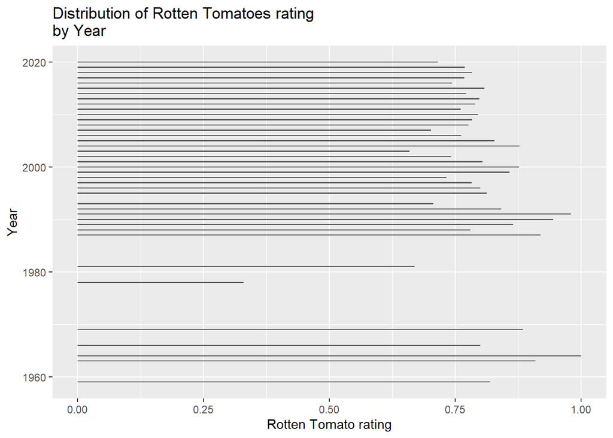

```r
p01 <- TV_shows[,] %>%
  select(Rotten.Tomatoes, Year) %>%
  group_by(Year) %>%
  summarise(mean.rate = mean(Rotten.Tomatoes, na.rm=TRUE)) %>%
  ggplot(aes(x=Year, y=mean.rate)) +
    geom_bar(stat = "identity", width=0.2)  +
    coord_flip()+
    xlab("Year") +
    ggtitle("Distribution of Rotten Tomatoes rating \nby Year") +
    scale_fill_brewer(palette="BuPu")+
    labs(y="Rotten Tomato rating")

# Display the plots.
grid.arrange(p01)
```

# Correlations

## Generate a correlation plot for the variables.

```r
# The 'corrplot' package provides the 'corrplot' function.
# Correlations work for numeric variables only.
#Pairwise comparison generally is any process of comparing entities in pairs to judge which of each entity is preferred, or has a greater amount of some quantitative property, or whether or not the two entities are identical.
SHOWcor <- cor(TV_shows[,c(SHOWnumeric, "Rotten.Tomatoes")], use="pairwise", method="pearson")
```

## Order the correlations by their strength.

```r
SHOWord <- order(SHOWcor[1,])
SHOWcor <- SHOWcor[SHOWord, SHOWord]
# Display the actual correlations.
print(SHOWcor)
```

```
##                     Disney.        Hulu     Netflix Prime.Video Rotten.Tomatoes
## Disney.          1.00000000 -0.08131321 -0.11910212 -0.14316334      0.02839698
## Hulu            -0.08131321  1.00000000 -0.39219032 -0.37522051      0.02009338
## Netflix         -0.11910212 -0.39219032  1.00000000 -0.50015993      0.01991487
## Prime.Video     -0.14316334 -0.37522051 -0.50015993  1.00000000     -0.01795260
## Rotten.Tomatoes  0.02839698  0.02009338  0.01991487 -0.01795260      1.00000000
## IMDb            -0.03327860 -0.03313436  0.03660799  0.03790924      0.48886940
##                        IMDb
## Disney.         -0.03327860
## Hulu            -0.03313436
## Netflix          0.03660799
## Prime.Video      0.03790924
## Rotten.Tomatoes  0.48886940
## IMDb             1.00000000
```

## Graphically display the correlations.

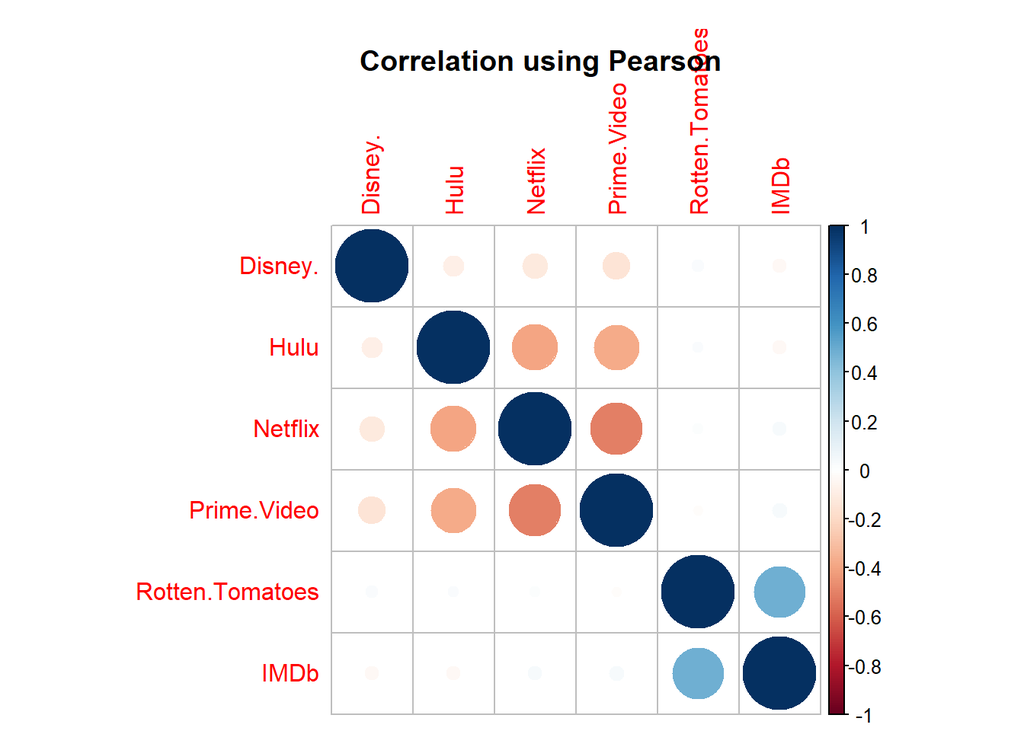

```r
corrplot(SHOWcor, mar=c(0,0,1,0))
title(main="Correlation using Pearson")
```

## Hierarchical Variable Correlation

### Generate the correlations (numerics only).

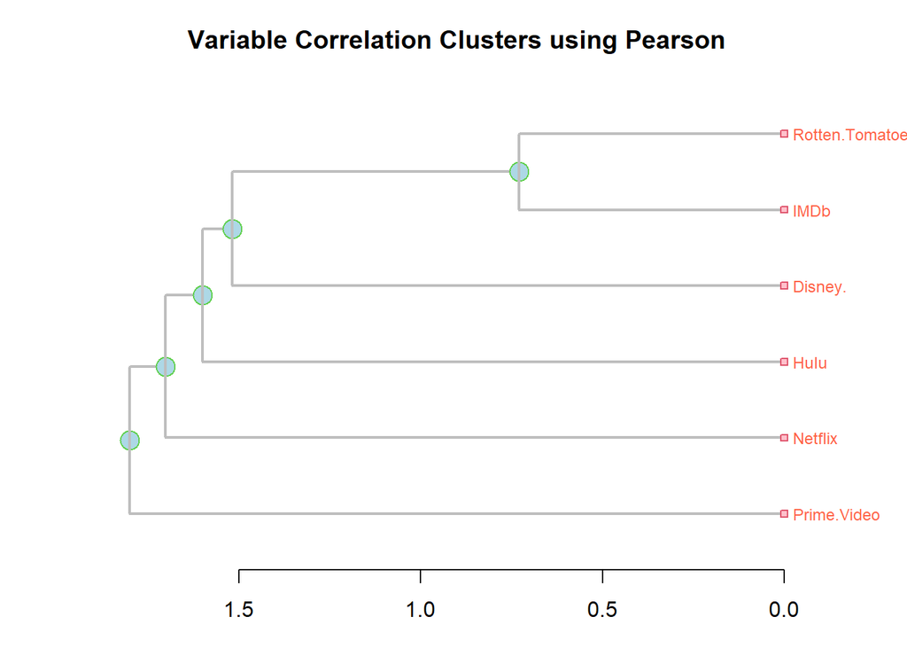

```r
cc <- cor(TV_shows[,c(SHOWnumeric, "Rotten.Tomatoes")], use="pairwise", method="pearson")

# Generate hierarchical cluster of variables.

hc <- hclust(dist(cc), method="average")

# Generate the dendrogram.

dn <- as.dendrogram(hc)

# Now draw the dendrogram.

op <- par(mar = c(3, 4, 3, 3.71))
plot(dn, horiz = TRUE, nodePar = list(col = 3:2, cex = c(2.0, 0.75), pch = 21:22, bg=  c("light blue", "pink"), lab.cex = 0.75, lab.col = "tomato"), edgePar = list(col = "gray", lwd = 2), xlab="Height")
title(main="Variable Correlation Clusters using Pearson")
```

```r
par(op) #par can be used to set or query graphical parameters.
```

# Models

## T-test

-t-test is a type of inferential statistic used to determine if there is a significant difference between the means of two groups, which may be related in certain features.  
- we reject H0 if alpha greater than p-value  
-H0-Null hypothesis: the average rating between two platforms is equal.  
-H1-Alternative hypothesis: the average rating on platform is greater than the other.  
We will test our assumption with a 95% confidence level.  
alpha = 5%  
Reject H0 if p value is less than 5%

```r
Platform_All=case_when(
    TV_shows$Netflix==1 & TV_shows$Hulu==0 & TV_shows$ Prime.Video==0 & TV_shows$'Disney.'==0 ~"Netflix",
    TV_shows$Netflix==0 & TV_shows$Hulu==1 & TV_shows$Prime.Video==0 & TV_shows$'Disney.'==0 ~"Hulu",
    TV_shows$Netflix==0 & TV_shows$Hulu==0 & TV_shows$Prime.Video==1 & TV_shows$'Disney.'==0 ~"Prime_Video",
    TV_shows$Netflix==0 & TV_shows$Hulu==0 & TV_shows$Prime.Video==0 & TV_shows$'Disney.'==1 ~"Disney+",
    TV_shows$Netflix==1 & TV_shows$Hulu==1 & TV_shows$Prime.Video==0 & TV_shows$'Disney.'==0 ~"Netflix&Hulu",
    TV_shows$Netflix==1 & TV_shows$Hulu==0 & TV_shows$Prime.Video==1 & TV_shows$'Disney.'==0 ~"Netflix&Prime",
    TV_shows$Netflix==1 & TV_shows$Hulu==0 & TV_shows$Prime.Video==0 & TV_shows$'Disney.'==1 ~"Netflix&Disney",
    TV_shows$Netflix==0 & TV_shows$Hulu==1 & TV_shows$Prime.Video==1 & TV_shows$'Disney.'==0 ~"Hulu&Prime",
    TV_shows$Netflix==0 & TV_shows$Hulu==1 & TV_shows$Prime.Video==0 & TV_shows$'Disney.'==1 ~"Hulu&Disney",
    TV_shows$Netflix==0 & TV_shows$Hulu==0 & TV_shows$Prime.Video==1 & TV_shows$'Disney.'==1 ~"Prime&Disney",
    TV_shows$Netflix==1 & TV_shows$Hulu==1 & TV_shows$Prime.Video==1 & TV_shows$'Disney.'==0 ~"Netflix&Hulu&Prime",
    TV_shows$Netflix==1 & TV_shows$Hulu==1 & TV_shows$Prime.Video==0 & TV_shows$'Disney.'==1 ~"Netflix&Hulu&Disney",
    TV_shows$Netflix==0 & TV_shows$Hulu==1 & TV_shows$Prime.Video==1 & TV_shows$'Disney.'==1 ~"Hulu&Prime&Disney",
    TV_shows$Netflix==1 & TV_shows$Hulu==1 & TV_shows$Prime.Video==1 & TV_shows$'Disney.'==1 ~"All Platforms")

TV_shows <-TV_shows %>%
  mutate(Platform_All)
Netflix_rate<-TV_shows[TV_shows$Platform_All == "Netflix","Rate"]
Hulu_rate <-TV_shows[TV_shows$Platform_All == "Hulu","Rate"]
Disney_rate<-TV_shows[TV_shows$Platform_All == "Disney+","Rate"]
Prime_rate<-TV_shows[TV_shows$Platform_All == "Prime_Video","Rate"]
```

-H0-Null hypothesis: the average rating on Netflix equal to Hulu’s rating.  
-H1-Alternative hypothesis: the average rating on Netflix is greater than Hulu’s PV of t-test of Netflix and Hulu is 0.0002101 <0.05 smaller than alpha (we reject H0).

```r
t.test(x = Netflix_rate,
       y = Hulu_rate,
       alternative = "greater")
```

```
##
##  Welch Two Sample t-test
##
## data:  Netflix_rate and Hulu_rate
## t = 3.5317, df = 2562.7, p-value = 0.0002101
## alternative hypothesis: true difference in means is greater than 0
## 95 percent confidence interval:
##  0.08358738        Inf
## sample estimates:
## mean of x mean of y
##  7.614539  7.458034
```

-H0-Null hypothesis: the average rating on Disney equal to hulu’s rating.  
-H1-Alternative hypothesis: the average rating on Disney is greater than Hulu’s PV of t-test of Disney and Hulu is 0.7872 >0.05 greater than alpha (5%)  
We will not reject H0.

```r
t.test(x = Disney_rate,
       y = Hulu_rate,
       alternative = "greater")
```

```
##
##  Welch Two Sample t-test
##
## data:  Disney_rate and Hulu_rate
## t = -0.79844, df = 184.9, p-value = 0.7872
## alternative hypothesis: true difference in means is greater than 0
## 95 percent confidence interval:
##  -0.2496928        Inf
## sample estimates:
## mean of x mean of y
##  7.376712  7.458034
```

H0-Null hypothesis: the average rating on prime_video equal to hulu’s rating.  
-H1-Alternative hypothesis: the average rating on prime_video is greater than Hulu’s PV of t-test of Prime_video and Hulu is 0.0002738 <0.05 smaller than alpha(5%) H0 is rejected.

```r
t.test(x = Prime_rate,
       y = Hulu_rate,
       alternative = "greater")
```

```
##
##  Welch Two Sample t-test
##
## data:  Prime_rate and Hulu_rate
## t = 3.4611, df = 2326, p-value = 0.0002738
## alternative hypothesis: true difference in means is greater than 0
## 95 percent confidence interval:
##  0.08962408        Inf
## sample estimates:
## mean of x mean of y
##  7.628885  7.458034
```

## F test

H0: No difference in variances of Hulu and Disney  
H1: there is difference in variances  
we didnt reject H0 because The p-value of F-test is 0.3984. It’s greater than the significance level alpha = 0.05.  
In conclusion, there is no significant difference between the variances of the two sets of data.

```r
var.test(x= Hulu_rate,y= Disney_rate ,alternative = "two.sided")
```

```
##
##  F test to compare two variances
##
## data:  Hulu_rate and Disney_rate
## F = 1.1169, num df = 1250, denom df = 145, p-value = 0.3984
## alternative hypothesis: true ratio of variances is not equal to 1
## 95 percent confidence interval:
##  0.8647226 1.4085343
## sample estimates:
## ratio of variances
##           1.116855
```

H0: No difference in variances of Netflix and Disney.  
H1: there is difference in variances  
we didnt reject H0 because The p-value of F-test is 0.5739 It’s greater than the significance level alpha = 0.05.  
In conclusion, there is no significant difference between the variances of the two sets of data.

```r
var.test(x= Netflix_rate,y= Disney_rate ,alternative = "two.sided")
```

```
##
##  F test to compare two variances
##
## data:  Netflix_rate and Disney_rate
## F = 0.93784, num df = 1636, denom df = 145, p-value = 0.5739
## alternative hypothesis: true ratio of variances is not equal to 1
## 95 percent confidence interval:
##  0.7280381 1.1787936
## sample estimates:
## ratio of variances
##           0.937843
```

H0: No difference in variances of Prime and Disney  
H1: there is difference in variances  
we didnt reject H0 because The p-value of F-test is 0.9441 It’s greater than the significance level alpha = 0.05.  
In conclusion, there is no significant difference between the variances of the two sets of data

```r
var.test(x= Prime_rate,y= Disney_rate ,alternative = "two.sided")
```

```
##
##  F test to compare two variances
##
## data:  Prime_rate and Disney_rate
## F = 1.0129, num df = 1093, denom df = 145, p-value = 0.9441
## alternative hypothesis: true ratio of variances is not equal to 1
## 95 percent confidence interval:
##  0.7829721 1.2799969
## sample estimates:
## ratio of variances
##           1.012873
```

## Regression model

### Linear Regression model.

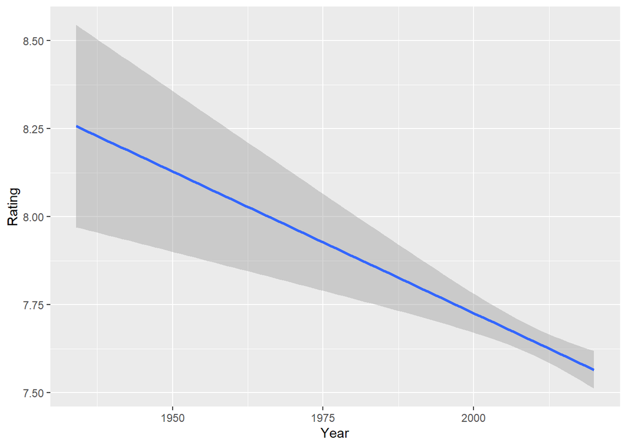

```r
TV_shows = TV_shows%>%
  mutate(Rating =ceiling(as.numeric(TV_shows$IMDb)))
Platform=case_when(
    TV_shows$Netflix ==1 & TV_shows$Hulu==0 & TV_shows$Prime.Video  ==0 & TV_shows$Disney.           == 0 ~"Netflix",
    TV_shows$Netflix ==0 & TV_shows$Hulu==1 & TV_shows$Prime.Video  ==0 & TV_shows$Disney. == 0 ~"Hulu",
    TV_shows$Netflix ==0 & TV_shows$Hulu==0 & TV_shows$Prime.Video  ==1 & TV_shows$Disney. == 0 ~"Prime Video",
   TV_shows$Netflix ==0 & TV_shows$Hulu==0 & TV_shows$Prime.Video  ==0 & TV_shows$Disney. == 1 ~"Disney+",TRUE ~ NA_character_)

data_rate<-TV_shows%>%
  mutate(Platform)%>%
  filter(!is.na(IMDb),!is.na(Age))%>%
  select(Title,Year,Age,Platform,Rotten.Tomatoes,Rating)


ggplot(data_rate, mapping = aes(x = Year, y = Rating)) +
  stat_smooth(method = "lm", formula = y~x)
```

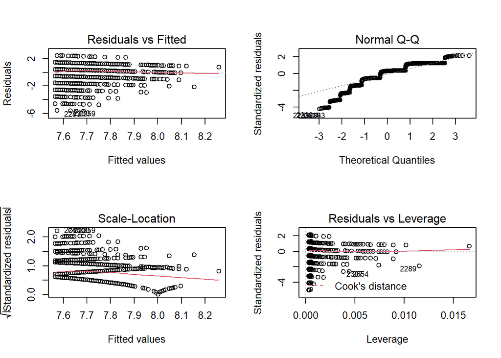

```r
model1 <- lm(formula = Rating ~ Year , data=data_rate)
par(mfrow=c(2,2)) # init 4 charts in 1 panel
plot(model1 )
```

```r
show(model1)
```

```
##
## Call:
## lm(formula = Rating ~ Year, data = data_rate)
##
## Coefficients:
## (Intercept)         Year
##   23.827650    -0.008051
```

```r
summary(model1)
```

```
##
## Call:
## lm(formula = Rating ~ Year, data = data_rate)
##
## Residuals:
##     Min      1Q  Median      3Q     Max
## -5.6864 -0.6058  0.3539  0.4264  2.4264
##
## Coefficients:
##              Estimate Std. Error t value Pr(>|t|)
## (Intercept) 23.827650   3.821194   6.236 5.10e-10 ***
## Year        -0.008051   0.001901  -4.236 2.35e-05 ***
## ---
## Signif. codes:  0 '***' 0.001 '**' 0.01 '*' 0.05 '.' 0.1 ' ' 1
##
## Residual standard error: 1.136 on 3134 degrees of freedom
## Multiple R-squared:  0.005692,   Adjusted R-squared:  0.005374
## F-statistic: 17.94 on 1 and 3134 DF,  p-value: 2.346e-05
```

*Coefficients:*  
The coefficients of the fitted function and how significant they are.

The model predicts with statistical significance that the variable Year is negatively associated to the Rating, more precisely, when the production year increases by one it is likely that the Rating will decrease by 0.008051.  
The Residuals against fitted values plot shows that the residuals are not evenly distributed over observations.

The second plot (normal Q-Q) is a normal probability plot.It will give a straight line if the errors are distributed normally, but points deviate from the straight line, indicating that our random values do not follow a normal distribution.

## Multiple linear regression

```r
model2<-lm(Rating ~ Year+ Age + Platform , data=data_rate)

par(mfrow=c(2,2)) # init 4 charts in 1 panel
plot(model2)

show(model2)
```

```
##
## Call:
## lm(formula = Rating ~ Year + Age + Platform, data = data_rate)
##
## Coefficients:
##         (Intercept)                 Year               Age16+
##             35.5295              -0.0146               1.5347
##              Age18+                Age7+               Ageall
##              1.6449               1.2420               1.0110
##        PlatformHulu      PlatformNetflix  PlatformPrime Video
##             -0.1028               0.1636               0.1693
```

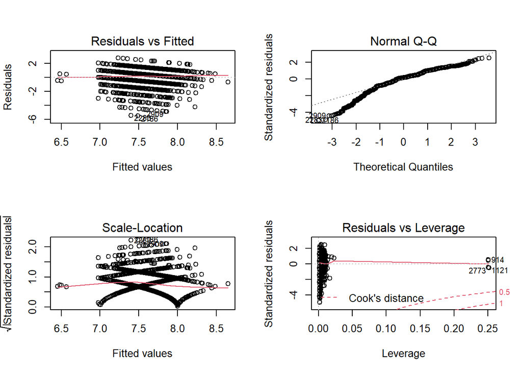

```r
plot(model2)
```

```r
summary(model2) # Generate a textual view of the Linear model.
```

```
##
## Call:
## lm(formula = Rating ~ Year + Age + Platform, data = data_rate)
##
## Residuals:
##     Min      1Q  Median      3Q     Max
## -5.4858 -0.5597  0.1837  0.6782  2.7658
##
## Coefficients:
##                      Estimate Std. Error t value Pr(>|t|)
## (Intercept)         35.529459   4.445841   7.992 1.91e-15 ***
## Year                -0.014599   0.002206  -6.617 4.37e-11 ***
## Age16+               1.534678   0.554185   2.769  0.00565 **
## Age18+               1.644897   0.554429   2.967  0.00303 **
## Age7+                1.241978   0.553956   2.242  0.02504 *
## Ageall               1.010990   0.554724   1.823  0.06848 .
## PlatformHulu        -0.102809   0.107635  -0.955  0.33958
## PlatformNetflix      0.163644   0.107406   1.524  0.12772
## PlatformPrime Video  0.169257   0.109933   1.540  0.12376
## ---
## Signif. codes:  0 '***' 0.001 '**' 0.01 '*' 0.05 '.' 0.1 ' ' 1
##
## Residual standard error: 1.103 on 2858 degrees of freedom
##   (269 observations deleted due to missingness)
## Multiple R-squared:  0.05347,    Adjusted R-squared:  0.05082
## F-statistic: 20.18 on 8 and 2858 DF,  p-value: < 2.2e-16
```

```r
AIC(model1)
```

```
## [1] 9705.001
```

```r
AIC(model2)
```

```
## [1] 8710.374
```

AIC The Akaike information criterion (AIC) is an estimator of prediction error and thereby relative quality of statistical models for a given set of data.

AIC is calculated from:

1. the number of independent variables used to build the model.
2. the maximum likelihood estimate of the model (how well the model reproduces the data).  
   We can see that model2 has a lower AIC value, thus it better than model1.

### Analysis of Variance

Analysis of Variance (ANOVA) consists of calculations that provide information about levels of variability within a regression model and form a basis for tests of significance. Our F-Value considered good (17.939) and the p-value is very low too,Thats mean that we will except that there is a relation between Year and Rating of the movie.

```r
cat('==== ANOVA ====')
```

```
## ==== ANOVA ====
```

```r
print(anova(model1))
```

```
## Analysis of Variance Table
##
## Response: Rating
##             Df Sum Sq Mean Sq F value    Pr(>F)
## Year         1   23.2 23.1631  17.939 2.346e-05 ***
## Residuals 3134 4046.6  1.2912
## ---
## Signif. codes:  0 '***' 0.001 '**' 0.01 '*' 0.05 '.' 0.1 ' ' 1
```